# ml_PLA_algo

## Problem 1.4

Generate a dataset of two-dimensional points, and choose a random line in the plane as your target function f, where one side of the line maps to +1 and the other side to −1. Let the inputs x n ∈ R 2 be random points in the plane, and evaluate the target function f on each x n to get the corresponding output y n = f(x n ).

Experiment with the perceptron learning algorithm in the following settings:

### a. Generate a dataset of size 20. Plot the examples {(x n , y n )} as well as the target function f on a plane.

```python
import numpy as np

def generate_pla_dataset(w, rows_num):
    '''
    TODO:
        generate a linear seprable dataset
    Method:
        random.uniform
    '''
    features_num = len(w) # num of x
    print('features_num=', features_num)
    dataset = np.zeros((rows_num, features_num + 1)) # with +1 row for y(+1 or -1)
    print('dataset shape=', dataset.shape)

    for i in range(rows_num):
        x = np.random.uniform(-1, 1, features_num)
        y = np.dot(w, x)
        y = 1 if np.sign(y) > 0 else -1 # sign(y) return +1 or -1
        dataset[i] = np.append(x, y)

    return dataset
```

```python
w_func = np.array([2.0, 3.0])
rows_num = 20
data = generate_pla_dataset(w_func, rows_num)
data[:5]
```

```
features_num= 2
dataset shape= (20, 3)
```

```
array([[ 0.67217417,  0.8305381 ,  1.        ],
       [-0.31733436, -0.62727665, -1.        ],
       [ 0.7505478 ,  0.27575261,  1.        ],
       [-0.91791374,  0.61036231, -1.        ],
       [-0.20113662, -0.19059412, -1.        ]])
```

```python
import matplotlib.pyplot as plt
from matplotlib.lines import Line2D

def pla_plot(dataset, w=None, w1=None):
    '''
    TODO:
        plot 2D with R^2 like (x1, x2, y)
    '''
    fig = plt.figure()
    ax = fig.add_subplot(111)
    ax.set_title('PLA')
    plt.xlabel('X')
    plt.ylabel('Y')

    labels = np.array(dataset[:, 2]) # index 2 is y(+1 or -1)
    print('labels=', labels)

    idx_1 = np.where(dataset[:,2]==1)
    idx_2 = np.where(dataset[:,2]==-1)
    plot_2D_x = 0 # index in dataset
    plot_2D_y = 1
    p1 = ax.scatter(dataset[idx_1, plot_2D_x], dataset[idx_1, plot_2D_y],
                    marker='o', color='g', label=1, s=20)
    p2 = ax.scatter(dataset[idx_2, plot_2D_x], dataset[idx_2, plot_2D_y],
                    marker='x', color='r', label=2, s=20)

    print('plot w=', w)
    ys = (-12 * (-w[0][0]) / w[0][1], 12 * (-w[0][0]) / w[0][1])
    ax.add_line(Line2D((-12, 12), ys, linewidth=1, color='blue'))

    if w1 != None:
        ys = (-12 * (-w1[0][0]) / w1[0][1], 12 * (-w1[0][0]) / w1[0][1])
        ax.add_line(Line2D((-12, 12), ys, linewidth=1, color='yellow'))

    plt.legend(loc = 'upper right')
    plt.show()
```

```
labels= [ 1. -1.  1. -1. -1.  1.  1.  1. -1. -1. -1.  1. -1.  1.  1.  1. -1. -1.
 -1. -1.]
plot w= [array([2., 3.])]
```

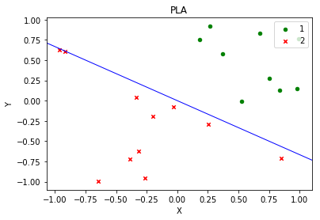

```python
pla_plot(data, [w_func])
```

### b.Run the perceptron algorithm on the dataset. Report the number of updates that the algorithm takes before converging. Plot the examples {(x n , y n )}, the target function f, and the ﬁnal hypothesis g in the same ﬁgure.

```python
def pla_train(dataset):
    '''
    train pla
    '''
    rows_num = dataset.shape[0]
    features_num = dataset.shape[1]
    w = np.zeros((1, features_num - 1)) # features_num - 1 for deleting y(+1, -1)
    finished = False

    i = 0
    count = 0
    while not finished and i < rows_num:
        x = dataset[i, 0:-1]
        y = dataset[i][-1]

        if y != np.sign(np.dot(w, x)):
            w = w + y*x
            finished = False
            i = 0;
        else:
            i += 1
        count += 1
    print('run all count=', count)
    return w
```

```python
w = pla_train(data)
```

```
run all count= 21
```

```python
w
```

```
array([[0.67217417, 0.8305381 ]])
```

```python
w[0]
```

```
array([0.67217417, 0.8305381 ])
```

```
labels= [ 1. -1.  1. -1. -1.  1.  1.  1. -1. -1. -1.  1. -1.  1.  1.  1. -1. -1.
 -1. -1.]
plot w= [array([2., 3.])]
```

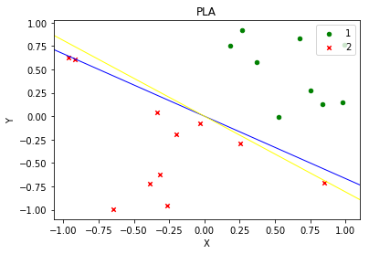

```python
pla_plot(data, [w_func], [w[0]])
```

### c. Repeat everything in b) with another randomly generated dataset of size 20, and compare the result to b).

```python
# datasize 100
data = generate_pla_dataset(w_func, 20)
data[:5]
```

```
features_num= 2
dataset shape= (20, 3)
```

```
array([[-0.39924724,  0.94281774,  1.        ],
       [-0.27422081,  0.90575455,  1.        ],
       [ 0.81181847,  0.00846891,  1.        ],
       [ 0.12169394, -0.5804301 , -1.        ],
       [-0.12295932, -0.14488604, -1.        ]])
```

```python
w = pla_train(data)
w
```

```
run all count= 87
```

```
array([[0.76637334, 1.20288871]])
```

```
labels= [ 1.  1.  1. -1. -1. -1. -1. -1. -1. -1. -1. -1.  1. -1. -1.  1.  1.  1.
 -1.  1.]
plot w= [array([2., 3.])]
```

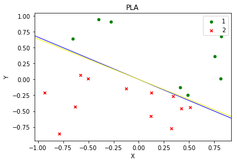

```python
pla_plot(data, [w_func], [w[0]])
```

### d. Repeat everything in b) with another randomly generated dataset of size 100, and compare the result to b).

```python
# datasize 100
data = generate_pla_dataset(w_func, 100)
data[:5]
```

```
features_num= 2
dataset shape= (100, 3)
```

```
array([[-0.25154344, -0.70637826, -1.        ],
       [-0.77403756,  0.57947207,  1.        ],
       [-0.2891648 ,  0.68931872,  1.        ],
       [ 0.32730194,  0.07682207,  1.        ],
       [ 0.59753574, -0.11572758,  1.        ]])
```

```
labels= [-1.  1.  1.  1.  1. -1.  1.  1.  1.  1.  1. -1. -1. -1.  1.  1. -1.  1.
 -1. -1.  1.  1.  1. -1.  1.  1.  1. -1. -1.  1. -1.  1. -1. -1.  1.  1.
 -1.  1.  1.  1. -1.  1. -1. -1. -1.  1. -1.  1. -1. -1.  1.  1.  1.  1.
  1.  1. -1.  1. -1. -1. -1.  1.  1. -1.  1. -1.  1.  1.  1. -1. -1. -1.
  1. -1.  1. -1. -1.  1.  1.  1. -1.  1. -1.  1.  1.  1. -1.  1.  1. -1.
 -1.  1. -1. -1.  1.  1. -1.  1. -1. -1.]
plot w= [array([2., 3.])]
```

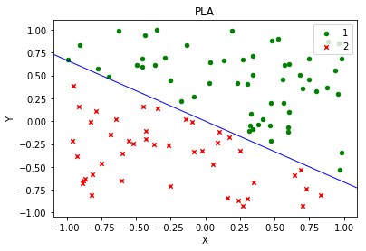

```python
pla_plot(data, [w_func])
```

```python
w = pla_train(data)
```

```
run all count= 191
```

```
labels= [-1.  1.  1.  1.  1. -1.  1.  1.  1.  1.  1. -1. -1. -1.  1.  1. -1.  1.
 -1. -1.  1.  1.  1. -1.  1.  1.  1. -1. -1.  1. -1.  1. -1. -1.  1.  1.
 -1.  1.  1.  1. -1.  1. -1. -1. -1.  1. -1.  1. -1. -1.  1.  1.  1.  1.
  1.  1. -1.  1. -1. -1. -1.  1.  1. -1.  1. -1.  1.  1.  1. -1. -1. -1.
  1. -1.  1. -1. -1.  1.  1.  1. -1.  1. -1.  1.  1.  1. -1.  1.  1. -1.
 -1.  1. -1. -1.  1.  1. -1.  1. -1. -1.]
plot w= [array([2., 3.])]
```

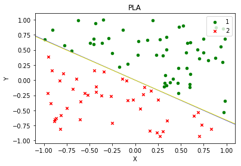

```python
pla_plot(data, [w_func], [w[0]])
```

### e. Repeat everything in b) with another randomly generated dataset of size 1000, and compare the result to b).

```python
# datasize 1000
data = generate_pla_dataset(w_func, 1000)
data[:5]
```

```
features_num= 2
dataset shape= (1000, 3)
```

```
array([[ 0.86057893, -0.51022768,  1.        ],
       [-0.07066097, -0.68714956, -1.        ],
       [ 0.0838874 ,  0.53485057,  1.        ],
       [-0.99099838,  0.943006  ,  1.        ],
       [-0.82631163,  0.33692382, -1.        ]])
```

[output not shown]

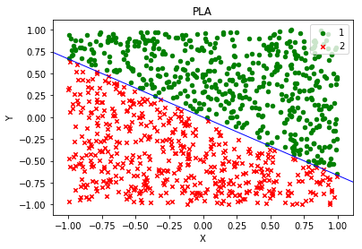

```python
pla_plot(data, [w_func])
```

```python
w = pla_train(data)
```

```
run all count= 6049
```

[output not shown]

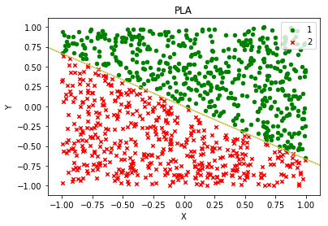

```python
pla_plot(data, [w_func], [w[0]])
```

### f. Modify the experiment such that x n ∈ R 10 instead of R 2 . Run the algorithm on a randomly generated dataset of size 1000. How many updates does the algorithm take to converge?

```python
# datasize 1000
data = generate_pla_dataset([2, 3, 4, 6, 10, 1, 2, 4, 5, 1], 1000)
data[:5]
```

```
features_num= 10
dataset shape= (1000, 11)
```

```
array([[-0.30301519,  0.04200453, -0.72136594, -0.62569036,  0.87355213,
         0.48898099, -0.97368827, -0.32070303,  0.83006381,  0.20494534,
         1.        ],
       [ 0.49994734, -0.65892856,  0.07495666,  0.64137051,  0.1845753 ,
        -0.33519348, -0.92124383,  0.58355927,  0.64129683, -0.76853683,
         1.        ],
       [-0.35591068, -0.39728985, -0.3657432 , -0.53809878, -0.76452749,
        -0.34311186, -0.4782564 ,  0.05958563, -0.20759659, -0.23483308,
        -1.        ],
       [ 0.74855322,  0.73973379,  0.60357061, -0.064519  , -0.29311958,
         0.44782525, -0.10844387, -0.92569672, -0.46468759, -0.71507108,
        -1.        ],
       [ 0.886616  , -0.26777952,  0.85234701,  0.81053802,  0.42517873,
        -0.15334403, -0.40534095,  0.37774097, -0.64191326,  0.26752492,
         1.        ]])
```

```python
w = pla_train(data)
```

```
run all count= 2368834
```

- updates 2368834 times to do the algorithm take to converge?

```python
w
```

```
array([[18.90151947, 29.66140776, 38.05839714, 57.53284234, 94.72866229,
         9.01883575, 19.56480003, 37.12407501, 46.82567062, 10.81661888]])
```

### g. Summarize your conclusions regarding the accuracy and running time of the algorithm as a function of N (the number of data points) and d (the number of dimensions).

| NO | N(points) | D(dimensions) | Times(converge) |
| --- | --- | --- | --- |
| b | 20 | 2 | 21 |
| c | 20 | 2 | 87 |
| d | 100 | 2 | 191 |
| e | 1000 | 2 | 6049 |
| f | 1000 | 10 | 2368834 |